# Part II - Explanatory Analysis of Loan Data from Prosper

## by Joachim Wambua

## Investigation Overview

#### Overall Goals of the presentation.

1. To understand the borrower and loan trends when Prosper offer's its loans to borrowers.
2. To identify the crucial features that affect the quality of loan a borrower receives.
3. To understand the underlying patterns in the Loaning System at Prosper.

#### Key Insights

During the analysis and visualization of Prosper's Loan Data, I found it imperative to evaluate the stand-out features that offered meaningful insight into the trends and patterns in the data.

1. Features `CreditGrade` & `BorrowerRate` gave great insight into how a Loan borrower's Credit Score/ `CreditGrade` could impact their Loan's interest rates. These features exhibited a negative correlation as it was observed that the higher a borrower's Credit Score the lower the interest rates they receive in their loans.
2. The features `LoanOriginalAmount` & `BorrowerRate` also exhibited a negative correlation as I found that higher borrower Loan Amounts mean that users received lower interest rates on their loans. Borrowers of higher amounts from Prosper often get the best/lowest interest rates.
3. There is evidence of positive correlation between the features `ProsperRating` which is a numerical format of the Credit Score rating and `LoanOriginalAmount` as borrowers with higher CreditScores/ ProsperRatings often borrowed large amounts of money compared to their lower rated counterparts.

## Dataset Overview

The Prosper Loan Dataset is a financial dataset with data related to loans and their characteristics such as interest rates, borrower information, lender information and more. The data was sourced from [Prosper Marketplace Inc](https://www.prosper.com/). which is a San Francisco, California based company offering loans at low interest rates to the borrowers. This dataset comprised of 81 variables and contains 113937 loan entries which can provide meaningful insights into the trends and patterns of Prosper's loans.

## 1. The Impact of Credit Score on a Loan's Interest Rate

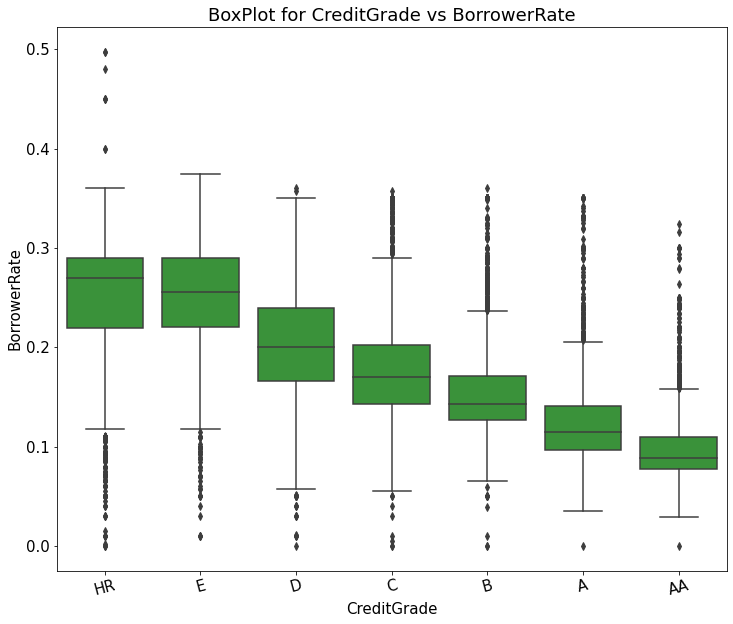

### Insight

When comparing numerical variable `BorrowerRate` vs categorical variable `CreditGrade` on a boxplot, the medians and inter-quartile ranges for BorrowerRate reduced as CreditGrades moved towards higher Credit Score classes (HR - AA). The Median values of `BorrowerRate` also decrease from Class HR through Class AA. This could mean that the Borrower Interest Rates are usually lower for higher ranked `CreditGrade` classes. I intend to carry this finding forward into the explanatory analysis

Features `CreditGrade` & `BorrowerRate` give insight into how a Loan borrower's Credit Score/ `CreditGrade` could impact their Loan's interest rates. These features exhibited a negative correlation as it was observed that the higher a borrower's Credit Score the lower the interest rates they receive in their loans.

## Investigating the relationship between a Loan Borrower's Amount Borrowed and Interest Rate given.

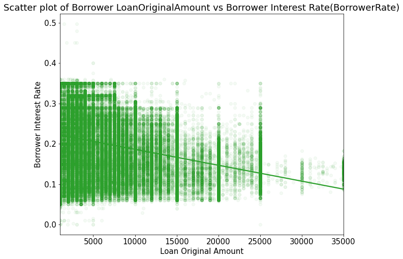

## Investigating whether Borrowers. with higher CreditScores/ProsperRating often borrow larger amounts of money.

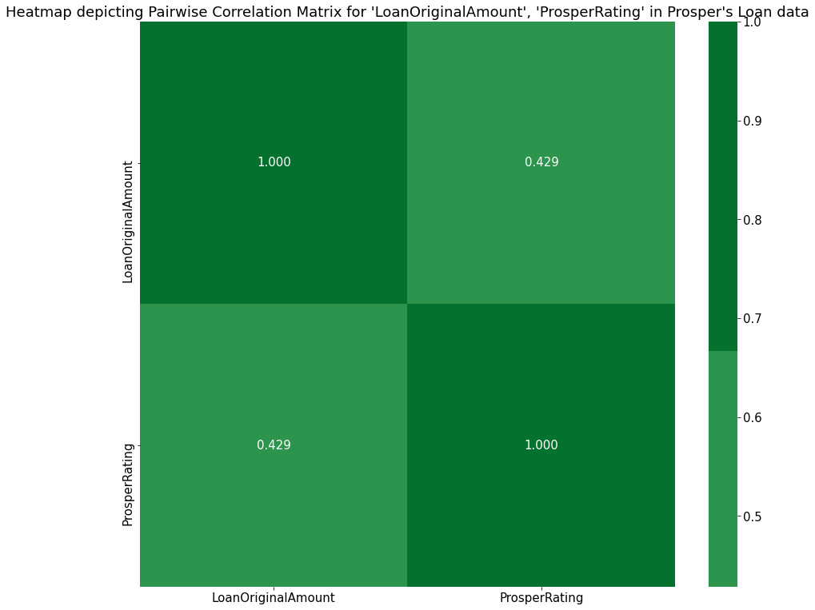

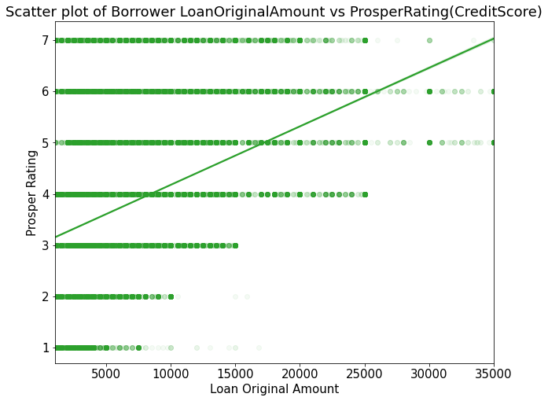

The correlation heatmap shows the variables `ProsperRating` and `LoanOriginalAmount` having a correlation coefficient of 0.429 which suggests a moderately positive correlation. The scatter plot right after the heatmap backs this finding as it shows a positive correlation between the two features.

There is evidence of positive correlation between the features `ProsperRating` which is a numerical format of the Credit Score rating and `LoanOriginalAmount` as borrowers with higher CreditScores/ ProsperRatings often borrowed large amounts of money compared to their lower rated counterparts.